# Final Report - Data Science

### SOCIOEMPRESA

> Se ele é sócio de uma empresa ou não.

```
Kurtosis Leptokurtic
Skew:
Mode: 277590
Mean: 0.08483997309807335
Median: 0.0
```

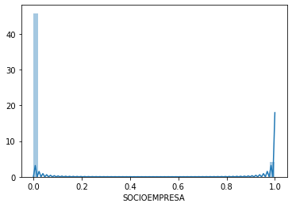

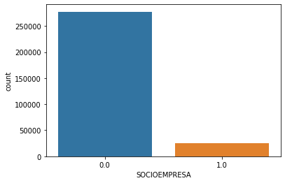

```python
univariableDetails(train_dataset['SOCIOEMPRESA'], 'categorical')
```

### FUNCIONARIOPUBLICO

> Se ele é funcionário público ou não.

```
Kurtosis Leptokurtic
Skew:
Mode: 275552
Mean: 0.0915588611517717
Median: 0.0
```

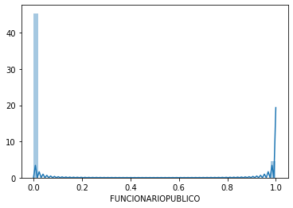

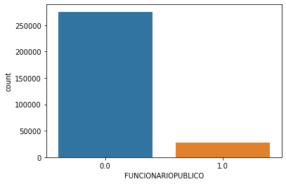

```python
univariableDetails(train_dataset['FUNCIONARIOPUBLICO'], 'categorical')
```

### MENORRENDACASA

> Qual é a menor renda da casa.

```
Kurtosis Leptokurtic
Skew: Positive assymetry
Mode: False
Mean: 1213.602587408794
Median: 900.0173161003479
```

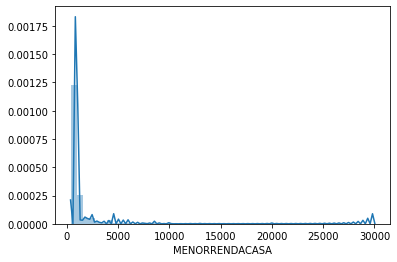

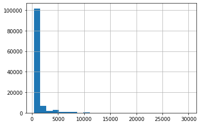

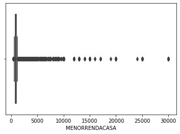

```python
univariableDetails(train_dataset['MENORRENDACASA'])
```

### INDICMENORDEIDADE

> Qual é o índice da menor idade.

```
Kurtosis Leptokurtic
Skew:
Mode: 108267
Mean: 0.06496299303042603
Median: 0.0
```

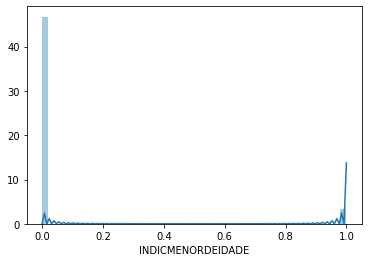

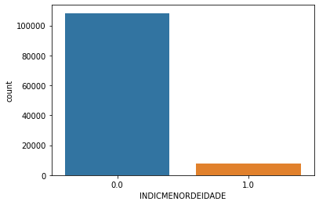

```python
univariableDetails(train_dataset['INDICMENORDEIDADE'], 'categorical')
```

### FUNCIONARIOPUBLICOCASA

> Se existe na casa um funcionário público.

```
Kurtosis Leptokurtic
Skew:
Mode: 92928
Mean: 0.19743671678656868
Median: 0.0
```

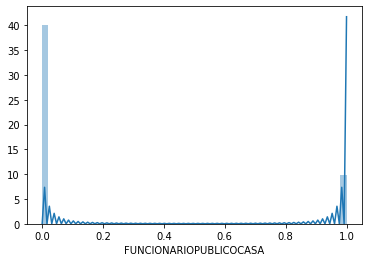

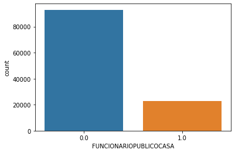

```python
univariableDetails(train_dataset['FUNCIONARIOPUBLICOCASA'], 'categorical')
```

### PERCENTANALFABETOCEP

> Percentual de pessoas que são analfabetas.

```
Kurtosis Leptokurtic
Skew: Positive assymetry
Mode: False
Mean: 0.15738267003731213
Median: 0.07755379375193378
```

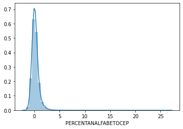

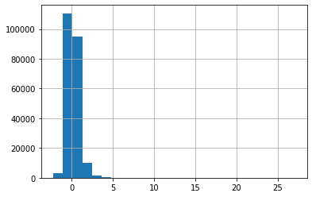

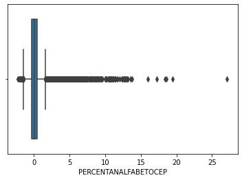

```python
univariableDetails(train_dataset['PERCENTANALFABETOCEP'])
```

### PERCENTFUNDAMENTALCEP

> Percentual de pessoas que possuem ensino fundamental.

```
Kurtosis Leptokurtic
Skew: Positive assymetry
Mode: False
Mean: 6.875825520537271
Median: 6.609434352151878
```

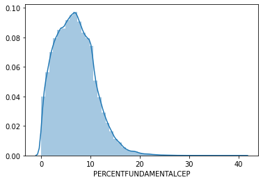

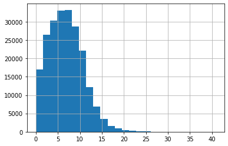

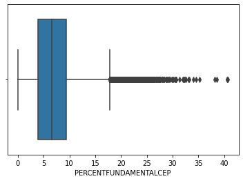

```python
univariableDetails(train_dataset['PERCENTFUNDAMENTALCEP'])
```

### PERCENTMEDIOCEP

> Percentual de pessoas que possuem o ensino médio.

```
Kurtosis Leptokurtic
Skew: Positive assymetry
Mode: False
Mean: 8.016336386356176
Median: 7.797888792467611
```

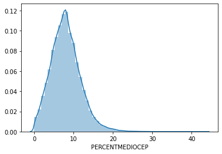

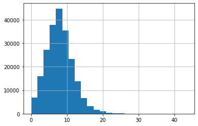

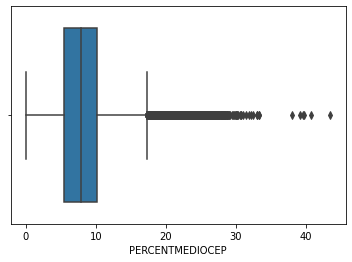

```python
univariableDetails(train_dataset['PERCENTMEDIOCEP'])
```

### PERCENTSUPERIORCEP

> Percentual de pessoas que possuem o ensino superior.

```
Kurtosis Leptokurtic
Skew: Positive assymetry
Mode: False
Mean: 3.6371561710308096
Median: 3.0796932754303583
```

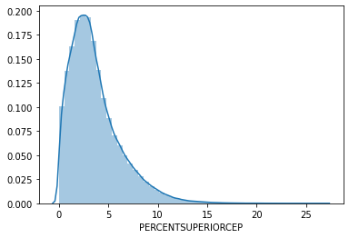

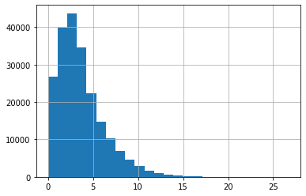

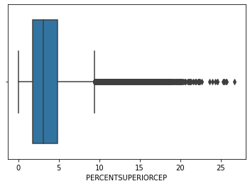

```python
univariableDetails(train_dataset['PERCENTSUPERIORCEP'])
```

### PERCENTBOLSAFAMILIACEP

> Percentual de pessoas que possuem o bolsa família por CEP

```
Kurtosis Leptokurtic
Skew: Positive assymetry
Mode: False
Mean: 4.338884698185077
Median: 3.0626306529202507
```

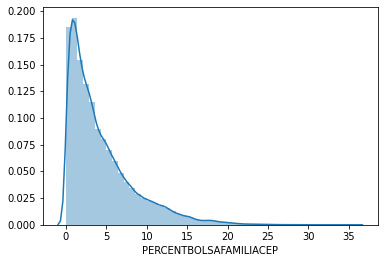

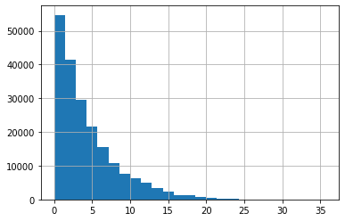

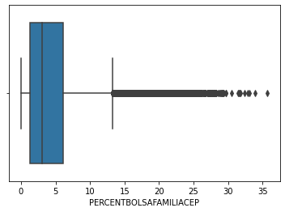

```python
univariableDetails(train_dataset['PERCENTBOLSAFAMILIACEP'])
```

### MEDIAIDADECASA

> Qual é a média de idade da casa.

```
Kurtosis Leptokurtic
Skew: Positive assymetry
Mode: False
Mean: 36.211859312766016
Median: 34.44063086702107
```

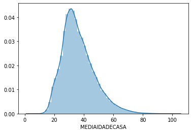

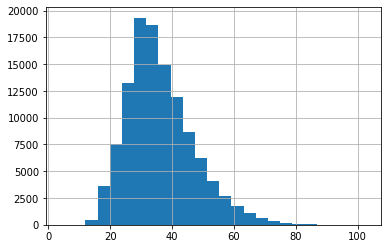

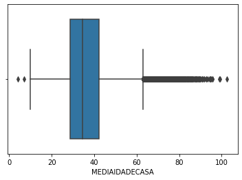

```python
univariableDetails(train_dataset['MEDIAIDADECASA'])
```

### MEDIARENDACASA

> Qual é a média da renda da casa.

```
Kurtosis Leptokurtic
Skew: Positive assymetry
Mode: False
Mean: 2904.787539849147
Median: 1799.7839816927703
```

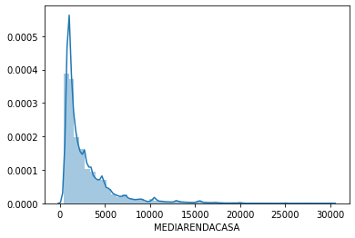

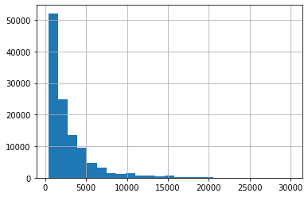

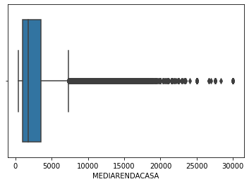

```python
univariableDetails(train_dataset['MEDIARENDACASA'])
```

### QTDAUTOMOVELMUNICIPIO

> Quantidade de automóvel no município.

```
Kurtosis Platykurtic
Skew: Negative assymetry
Mode: 9274
Mean: 294.6895225363836
Median: 323.0
```

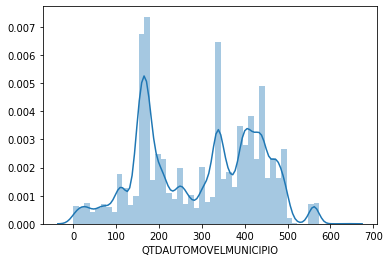

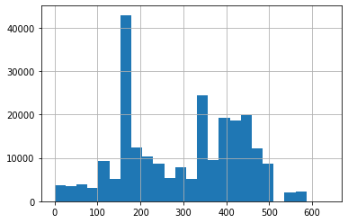

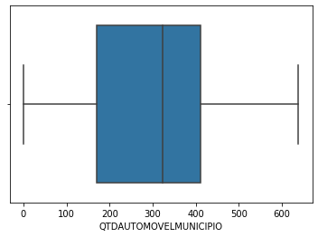

```python
univariableDetails(train_dataset['QTDAUTOMOVELMUNICIPIO'])
```

# Multivariate data analysis

In this section, you should plot at least 8 multivariate visualizations. The key here is to investigate underlying correlations and behaviors in the dataset. Naturally, as visualizations are being created, we should end up with obvious results, yet, you should find at least **TWO** non-obvious behavior in data.

Please follow these steps for creating your visualizations:

1. State an hypothesis. The key here is to explain why you are choosing those specific variables together and what you are expecting to find.
2. Determine what kind of visualization is the most suited.
3. Report the findings and whether they corroborate or not the aforestated hypothesis.

### Hints

In this section, make sure you go beyond naive explorations. For instance, try PCA, t-SNE, and even other techniques we have not worked with during the lectures. The key here is to start to develop a critical mindset towards data analysis and our own work.

### Important

It is strictly forbidden to create multivariate visualizations using variables that were not used in the previous section (univariate analysis).

```python
from statsmodels.stats.outliers_influence import variance_inflation_factor
train_dataset.fillna(train_dataset.mean(), inplace=True)
```

```python
pd.set_option('display.max_colwidth',1000)
pd.set_option('display.max_rows',1000)

def calc_vif(tabela):
  vif = pd.DataFrame()
  vif['variaveis'] = tabela.columns
  vif['vif'] = [variance_inflation_factor(tabela.values, i) for i in range(tabela.shape[1])]
  return vif

calc_vif(train_dataset)
```

|  | variaveis | vif |
| --- | --- | --- |
| 0 | HS_CPF | 3.481947 |
| 1 | TEMPOCPF | 8.370491 |
| 2 | DISTCENTROCIDADE | 2.603500 |
| 3 | DISTZONARISCO | 2.532197 |
| 4 | QTDENDERECO | 2.183395 |
| 5 | QTDEMAIL | 1.654427 |
| 6 | QTDCELULAR | 1.950437 |
| 7 | CELULARPROCON | 1.051039 |
| 8 | QTDFONEFIXO | 2.474411 |
| 9 | TELFIXOPROCON | 1.080374 |
| 10 | INDICEEMPREGO | 2.783485 |
| 11 | PORTEEMPREGADOR | 2.147120 |
| 12 | SOCIOEMPRESA | 1.266894 |
| 13 | FUNCIONARIOPUBLICO | 2.112846 |
| 14 | SEGMENTACAO | 13.158863 |
| 15 | SEGMENTACAOCOBRANCA | 1.370289 |
| 16 | SEGMENTACAOECOM | 2.965756 |
| 17 | SEGMENTACAOFIN | 1.465128 |
| 18 | SEGMENTACAOTELECOM | 8.299850 |
| 19 | QTDPESSOASCASA | 47.704979 |
| 20 | MENORRENDACASA | 9.191121 |
| 21 | MAIORRENDACASA | 54.904997 |
| 22 | SOMARENDACASA | 49.549785 |
| 23 | MEDIARENDACASA | 73.496786 |
| 24 | MAIORIDADECASA | 349.202049 |
| 25 | MENORIDADECASA | 114.526274 |
| 26 | MEDIAIDADECASA | 670.527710 |
| 27 | INDICMENORDEIDADE | 1.270051 |
| 28 | COBRANCABAIXOCASA | 1.241601 |
| 29 | COBRANCAMEDIOCASA | 1.025580 |
| 30 | COBRANCAALTACASA | 1.028984 |
| 31 | SEGMENTACAOFINBAIXACASA | 1.469108 |
| 32 | SEGMENTACAOFINMEDIACASA | 1.010170 |
| 33 | SEGMENTACAOALTACASA | 1.002285 |
| 34 | BOLSAFAMILIACASA | 2.165201 |
| 35 | FUNCIONARIOPUBLICOCASA | 2.184834 |
| 36 | IDADEMEDIACEP | 166.407187 |
| 37 | PERCENTMASCCEP | 403.783758 |
| 38 | PERCENTFEMCEP | 365.162468 |
| 39 | PERCENTANALFABETOCEP | 1.197633 |
| 40 | PERCENTPRIMARIOCEP | 4.527044 |
| 41 | PERCENTFUNDAMENTALCEP | 9.404285 |
| 42 | PERCENTMEDIOCEP | 12.768909 |
| 43 | PERCENTSUPERIORCEP | 6.293733 |
| 44 | PERCENTMESTRADOCEP | 1.157763 |
| 45 | PERCENTDOUTORADOCEP | 4.978261 |
| 46 | PERCENTBOLSAFAMILIACEP | 6.159005 |
| 47 | PERCENTFUNCIONARIOPUBLICOCEP | 2.692366 |
| 48 | MEDIARENDACEP | 26.117360 |
| 49 | PIBMUNICIPIO | 10.646221 |
| 50 | QTDUTILITARIOMUNICIPIO | 9.237952 |
| 51 | QTDAUTOMOVELMUNICIPIO | 40.204919 |
| 52 | QTDCAMINHAOMUNICIPIO | 21.066333 |
| 53 | QTDCAMINHONETEMUNICIPIO | 77.936607 |
| 54 | QTDMOTOMUNICIPIO | 14.218734 |
| 55 | PERCENTPOPZONAURBANA | 140.262903 |
| 56 | IDHMUNICIPIO | 1632.551055 |
| 57 | ESTIMATIVARENDA | 2.668095 |
| 58 | QTDDECLARACAOISENTA | 2.364174 |
| 59 | QTDDECLARACAO10 | 5.835184 |
| 60 | QTDDECLARACAOREST10 | 3.778878 |
| 61 | QTDDECLARACAOPAGAR10 | 2.782429 |
| 62 | RESTITUICAOAGENCIAALTARENDA | 1.049863 |
| 63 | BOLSAFAMILIA | 1.171858 |
| 64 | ANOSULTIMARESTITUICAO | 7.363146 |
| 65 | ANOSULTIMADECLARACAO | 5.949242 |
| 66 | ANOSULTIMADECLARACAOPAGAR | 17.234152 |
| 67 | TARGET | 1.130494 |

### 1. IDHMUNICIPIO - QTDAUTOMOVELMUNICIPIO

> Porquê: Analisar se o IDH do munícipio influencia na quantidade de veículos.

> Hipótese: Quanto maior o IDH, menos veículos. (Mais IDH: mais segurança, mais transporte público).

> Confirmação: Não, já que quanto maior o IDH maior a quantidade de veículos

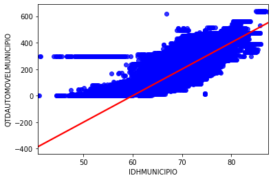

```python
sns.regplot(train_dataset['IDHMUNICIPIO'], train_dataset['QTDAUTOMOVELMUNICIPIO'], scatter_kws={"color": "blue"}, line_kws={"color": "red"})
plt.show()
```

### 2. MEDIAIDADECASA - MEDIARENDACASA

> Porquê: Analisar uma correlação entre idade e salário.

> Hipótese: Quanto maior idade, maior a renda.

> Confirmação: Não, pois após aos 70 anos a renda passa a diminuir.

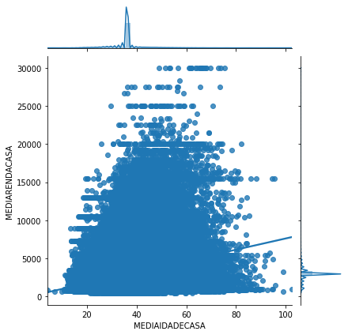

```python
sns.jointplot(data=train_dataset, x='MEDIAIDADECASA', y='MEDIARENDACASA', kind='reg')
plt.show()
```

### 3. BOLSAFAMILIA - FUNCIONARIOPUBLICO

> Porquê: Analisar se existe alguma possibilidade de irregularidade no bolsa família (funcionários públicos não deveriam receber bolsa família)

> Hipotese: Ninguém que é funcionário público tem bolsa família

> Confirmação: Não, pois existem 211 pessoas que são funcionários públicos e tem o benefício do bolsa família.

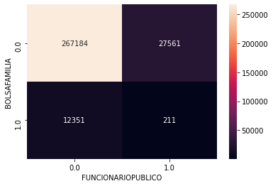

```python
ctab = pd.crosstab(train_dataset['BOLSAFAMILIA'], train_dataset['FUNCIONARIOPUBLICO'])
sns.heatmap(ctab, annot=True, fmt='g')
plt.show()
```

### 4. QTDPESSOASCASA - SOMARENDACASA

> Porquê: Analisar se quanto mais pessoas existirem na casa, maior a renda

> Hipótese: Quanto mais pessoas, maior a renda.

> Confirmação: Sim, quanto mais pessoas na casa maior a renda.

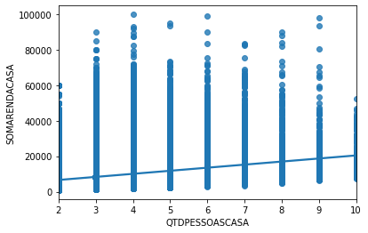

```python
sns.regplot(train_dataset['QTDPESSOASCASA'], train_dataset['SOMARENDACASA'])
plt.show()
```

### 5. IDHMUNICIPIO - PIBMUNCIPIO

> Porquê: Analisar se o IDH acompanha o PIB.

> Hipótose: Quanto maior o PIB, maior o IDH.

> Confirmação: Sim, quanto maior PIB maior o IDH.

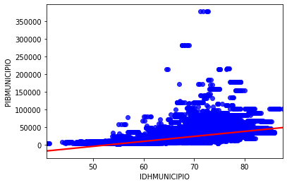

```python
sns.regplot(train_dataset['IDHMUNICIPIO'], train_dataset['PIBMUNICIPIO'], scatter_kws={"color": "blue"}, line_kws={"color": "red"})
plt.show()
```

### 6. FUNCIONARIOPUBLICO - TARGET

> Porquê: Analisar funcionários públicos que são adimplentes ou inadimplentes.

> Hipótese: A maioria dos funcionários públicos não são inadimplentes.

> Confirmação: Sim, 94% dos funcionãrios são adimplentes.

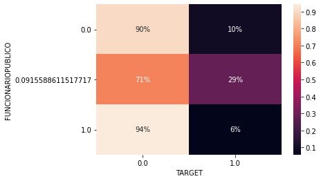

```python
ctab = pd.crosstab(train_dataset['FUNCIONARIOPUBLICO'], train_dataset['TARGET'], normalize='index')
sns.heatmap(ctab, annot=True, fmt='.0%')
plt.show()
```

### 7. IDHMUNICIPIO - PERCENTSUPERIORCEP

> Porquê: Analisar a relação entre o IDH e a porcentagem de pessoas no ensino superior.

> Hipótese: Quanto maior o IDH, mais pessoas no ensino superior.

> Confirmação: Sim, quanto maior o IDH mais pessoas no ensino superior.

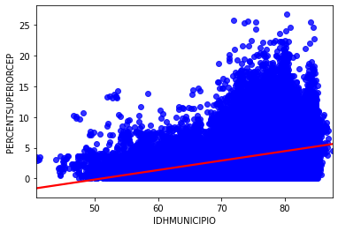

```python
sns.regplot(train_dataset['IDHMUNICIPIO'], train_dataset['PERCENTSUPERIORCEP'], scatter_kws={"color": "blue"}, line_kws={"color": "red"})
plt.show()
```

### 8. PIBMUNICIPIO - PERCENTSUPERIORCEP

> Porquê: Analisar a relação entre o PIB e a porcentagem de pessoas no ensino superior.

> Hipótese: Quanto maior o PIB, mais pessoas no ensino superior.

> Confirmação: Sim, quanto maior o PIB, mais pessoas no ensino superior.

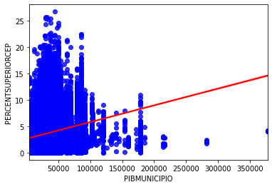

```python
sns.regplot(train_dataset['PIBMUNICIPIO'], train_dataset['PERCENTSUPERIORCEP'], scatter_kws={"color": "blue"}, line_kws={"color": "red"})
plt.show()
```